# Formative Assessment 3

PATAYON, SPIKE LEE-ROY V

2026-02-19

## Case Study: Payroll and Wins in Major League Baseball (1998–2014)

You will investigate whether higher payroll leads to higher win percentage among MLB teams.

You must:

- Tidy the data
- Validate aggregates
- Build regression models
- Perform diagnostic checks
- Interpret results critically

Load necessary libraries

```r
library(ggplot2)
library(tidyverse)
library(ggrepel)
library(broom)
library(cowplot)
library(car) # for VIF & diagnostics
library(performance) # optional for model checks
```

# **Part 1 – Data Wrangling and Validation (6 points)**

### 1.1 Import & Structure (2 points)

- Import as `mlb_raw`.

  ```r
  load("C:\\Users\\spike\\Downloads\\ml_pay.rdata")
  mlb_raw <- ml_pay
  mlb_raw
  ```

  ```
  ##      payroll    avgwin        Team.name.2014    p1998    p1999    p2000
  ## 1  1.1208736 0.4902585  Arizona Diamondbacks 31.61450 70.49600 81.02783
  ## 2  1.3817118 0.5527605        Atlanta Braves 61.70800 74.89000 84.53784
  ## 3  1.1612117 0.4538250     Baltimore Orioles 71.86092 72.19836 81.44743
  ## 4  1.9723587 0.5487172        Boston Red Sox 59.49700 71.72500 77.94033
  ## 5  1.4597668 0.4736557          Chicago Cubs 49.81600 42.14276 60.53933
  ## 6  1.3153909 0.5111170     Chicago White Sox 35.18000 24.53500 31.13350
  ## 7  1.0247816 0.4861602       Cincinnati Reds 20.70733 73.27846 46.86720
  ## 8  0.9991810 0.4959225     Cleveland Indians 59.54317 54.44250 75.88087
  ## 9  1.0261536 0.4633760      Colorado Rockies 47.71465 55.44350 61.11119
  ## 10 1.4297408 0.4822029        Detroit Tigers 19.23750 34.95967 58.26517
  ## 11 1.0601501 0.4687202        Houston Astros 48.30400 54.33900 51.28911
  ## 12 0.8177417 0.4342288    Kansas City Royals 35.61000 16.55700 23.43300
  ## 13 1.5626224 0.5463819    Los Angeles Angels 48.38900 49.86817 51.46417
  ## 14 1.7402719 0.5308482   Los Angeles Dodgers 62.80667 71.11579 88.12429
  ```

  [output cut: 202 more lines]

  ```r
  colnames(mlb_raw)
  ```

  ```
  ##  [1] "payroll"        "avgwin"         "Team.name.2014" "p1998"
  ##  [5] "p1999"          "p2000"          "p2001"          "p2002"
  ##  [9] "p2003"          "p2004"          "p2005"          "p2006"
  ## [13] "p2007"          "p2008"          "p2009"          "p2010"
  ## [17] "p2011"          "p2012"          "p2013"          "p2014"
  ## [21] "X2014"          "X2013"          "X2012"          "X2011"
  ## [25] "X2010"          "X2009"          "X2008"          "X2007"
  ## [29] "X2006"          "X2005"          "X2004"          "X2003"
  ## [33] "X2002"          "X2001"          "X2000"          "X1999"
  ## [37] "X1998"          "X2014.pct"      "X2013.pct"      "X2012.pct"
  ## [41] "X2011.pct"      "X2010.pct"      "X2009.pct"      "X2008.pct"
  ## [45] "X2007.pct"      "X2006.pct"      "X2005.pct"      "X2004.pct"
  ## [49] "X2003.pct"      "X2002.pct"      "X2001.pct"      "X2000.pct"
  ## [53] "X1999.pct"      "X1998.pct"
  ```

- Report dimensions and variable types.

  ```r
  dim(mlb_raw)
  ```

  ```
  ## [1] 30 54
  ```

  ```r
  str(mlb_raw)
  ```

  ```
  ## 'data.frame':    30 obs. of  54 variables:
  ##  $ payroll       : num  1.12 1.38 1.16 1.97 1.46 ...
  ##  $ avgwin        : num  0.49 0.553 0.454 0.549 0.474 ...
  ##  $ Team.name.2014: Factor w/ 30 levels "Arizona Diamondbacks",..: 1 2 3 4 5 6 7 8 9 10 ...
  ##  $ p1998         : num  31.6 61.7 71.9 59.5 49.8 ...
  ##  $ p1999         : num  70.5 74.9 72.2 71.7 42.1 ...
  ##  $ p2000         : num  81 84.5 81.4 77.9 60.5 ...
  ##  $ p2001         : num  81.2 91.9 72.4 109.6 64 ...
  ##  $ p2002         : num  102.8 93.5 60.5 108.4 75.7 ...
  ##  $ p2003         : num  80.6 106.2 73.9 99.9 79.9 ...
  ##  $ p2004         : num  70.2 88.5 51.2 125.2 91.1 ...
  ##  $ p2005         : num  63 85.1 74.6 121.3 87.2 ...
  ##  $ p2006         : num  59.7 90.2 72.6 120.1 94.4 ...
  ##  $ p2007         : num  52.1 87.3 93.6 143 99.7 ...
  ##  $ p2008         : num  66.2 102.4 67.2 133.4 118.3 ...
  ```

  [output cut: 40 more lines]

  ```r
  glimpse(mlb_raw)
  ```

  ```
  ## Rows: 30
  ## Columns: 54
  ## $ payroll        <dbl> 1.1208736, 1.3817118, 1.1612117, 1.9723587, 1.4597668, …
  ## $ avgwin         <dbl> 0.4902585, 0.5527605, 0.4538250, 0.5487172, 0.4736557, …
  ## $ Team.name.2014 <fct> Arizona Diamondbacks, Atlanta Braves, Baltimore Orioles…
  ## $ p1998          <dbl> 31.61450, 61.70800, 71.86092, 59.49700, 49.81600, 35.18…
  ## $ p1999          <dbl> 70.49600, 74.89000, 72.19836, 71.72500, 42.14276, 24.53…
  ## $ p2000          <dbl> 81.02783, 84.53784, 81.44743, 77.94033, 60.53933, 31.13…
  ## $ p2001          <dbl> 81.20651, 91.85169, 72.42633, 109.55891, 64.01583, 62.3…
  ## $ p2002          <dbl> 102.82000, 93.47037, 60.49349, 108.36606, 75.69083, 57.…
  ## $ p2003          <dbl> 80.64033, 106.24367, 73.87750, 99.94650, 79.86833, 51.0…
  ## $ p2004          <dbl> 70.20498, 88.50779, 51.21265, 125.20854, 91.10167, 65.2…
  ## $ p2005          <dbl> 63.01583, 85.14858, 74.57054, 121.31194, 87.21093, 75.2…
  ## $ p2006          <dbl> 59.68423, 90.15688, 72.58558, 120.09982, 94.42450, 102.…
  ## $ p2007          <dbl> 52.06755, 87.29083, 93.55481, 143.02621, 99.67033, 108.…
  ```

  [output cut: 41 more lines]

- Briefly comment on structure.

  The dataset contains 30 observations (rows) representing Major League Baseball teams and 54 variables (columns). The data are currently structured in a wide format, where each team occupies one row and yearly information (1998–2014) is spread across multiple columns.

  Payroll, wins, and win percentage for each year are stored as separate variables (e.g., p1998, X1998, X1998.pct).

  This structure is not ideal for regression analysis because it does not follow tidy data principles. To properly analyze payroll and win percentage relationships, the dataset must be reshaped into a long (panel) format, where each row represents a team year observation.

### 1.2 Tidy Data (4 points)

**`mlb_yearly`**

- team
- year
- payroll
- pct_wins
- num_wins

Rename team column first:

```r
mlb_clean <- mlb_raw %>%
  rename(team = Team.name.2014)
```

Pivot payroll columns (p1998-p2014)

```r
payroll_long <- mlb_clean %>%
  select(team, matches("^p[0-9]{4}$")) %>%
  pivot_longer(
    cols = -team,
    names_to = "year",
    values_to = "payroll"
  ) %>%
  mutate(year = as.numeric(str_remove(year, "p")))
```

Pivot wins columns (x1998-x2014)

```r
wins_long <- mlb_clean %>%
  select(team, starts_with("X"), -contains("pct")) %>%
  pivot_longer(
    cols = starts_with("X"),
    names_to = "year",
    values_to = "num_wins"
  ) %>%
  mutate(year = as.numeric(str_remove(year, "X")))
```

Pivot win percentage columns (X1998.pct–X2014.pct)

```r
pct_long <- mlb_clean %>%
  select(team, contains(".pct")) %>%
  pivot_longer(
    cols = contains(".pct"),
    names_to = "year",
    values_to = "pct_wins"
  ) %>%
  mutate(year = as.numeric(str_remove_all(year, "X|\\.pct")))
```

Merge everything together

```r
mlb_yearly <- payroll_long %>%
  left_join(wins_long, by = c("team", "year")) %>%
  left_join(pct_long, by = c("team", "year")) %>%
  arrange(team, year)
```

```r
dim(mlb_yearly)
```

```
## [1] 510   5
```

```r
colnames(mlb_yearly)
```

```
## [1] "team"     "year"     "payroll"  "num_wins" "pct_wins"
```

```r
mlb_yearly
```

```
## # A tibble: 510 × 5
##    team                  year payroll num_wins pct_wins
##    <fct>                <dbl>   <dbl>    <int>    <dbl>
##  1 Arizona Diamondbacks  1998    31.6       65    0.399
##  2 Arizona Diamondbacks  1999    70.5      100    0.613
##  3 Arizona Diamondbacks  2000    81.0       85    0.525
##  4 Arizona Diamondbacks  2001    81.2       92    0.568
##  5 Arizona Diamondbacks  2002   103.        98    0.605
##  6 Arizona Diamondbacks  2003    80.6       84    0.519
##  7 Arizona Diamondbacks  2004    70.2       51    0.315
##  8 Arizona Diamondbacks  2005    63.0       77    0.475
##  9 Arizona Diamondbacks  2006    59.7       76    0.469
## 10 Arizona Diamondbacks  2007    52.1       90    0.552
## # ℹ 500 more rows
```

Create:

**`mlb_aggregate`**

- team
- payroll_aggregate
- pct_wins_aggregate

  ```r
  mlb_aggregate <- mlb_yearly %>%
    group_by(team) %>%
    summarise(
      payroll_aggregate = sum(payroll, na.rm = TRUE),
      pct_wins_aggregate = mean(pct_wins, na.rm = TRUE),
      .groups = "drop"
    )
  ```

```r
dim(mlb_aggregate)
```

```
## [1] 30  3
```

```r
colnames(mlb_aggregate)
```

```
## [1] "team"               "payroll_aggregate"  "pct_wins_aggregate"
```

```r
mlb_aggregate
```

```
## # A tibble: 30 × 3
##    team                 payroll_aggregate pct_wins_aggregate
##    <fct>                            <dbl>              <dbl>
##  1 Arizona Diamondbacks             1223.              0.492
##  2 Atlanta Braves                   1518.              0.563
##  3 Baltimore Orioles                1305.              0.457
##  4 Boston Red Sox                   2104.              0.551
##  5 Chicago Cubs                     1552.              0.475
##  6 Chicago White Sox                1375.              0.507
##  7 Cincinnati Reds                  1119.              0.491
##  8 Cleveland Indians                1113.              0.505
##  9 Colorado Rockies                 1129.              0.463
## 10 Detroit Tigers                   1484.              0.474
## # ℹ 20 more rows
```

The original data set was in wide format, where yearly payroll, wins, and win percentages were stored as separate columns. The data were reshaped into long format to satisfy tidy data principles, such that each row represents a single team–year observation.

Since the data set includes 30 MLB teams and covers 17 seasons (1998–2014), the expected number of observations is:

30 × 17 = 510.

The resulting mlb_yearly dataset contains 510 rows and 5 variables (team, year, payroll, pct_wins, num_wins), confirming a balanced panel data set appropriate for regression analysis.

The mlb_aggregate data set summarizes each team’s total payroll and average win percentage across all seasons.

# **Part 2 – Aggregate Consistency Check (4 points)**

1. Compute aggregates from `mlb_yearly`.

   ```r
   mlb_computed <- mlb_yearly %>%
     group_by(team) %>%
     summarise(
       payroll_computed = sum(payroll, na.rm = TRUE),
       pct_wins_computed = mean(pct_wins, na.rm = TRUE),
       .groups = "drop"
     )
   ```

   ```r
   mlb_computed
   ```

   ```
   ## # A tibble: 30 × 3
   ##    team                 payroll_computed pct_wins_computed
   ##    <fct>                           <dbl>             <dbl>
   ##  1 Arizona Diamondbacks            1223.             0.492
   ##  2 Atlanta Braves                  1518.             0.563
   ##  3 Baltimore Orioles               1305.             0.457
   ##  4 Boston Red Sox                  2104.             0.551
   ##  5 Chicago Cubs                    1552.             0.475
   ##  6 Chicago White Sox               1375.             0.507
   ##  7 Cincinnati Reds                 1119.             0.491
   ##  8 Cleveland Indians               1113.             0.505
   ##  9 Colorado Rockies                1129.             0.463
   ## 10 Detroit Tigers                  1484.             0.474
   ## # ℹ 20 more rows
   ```

2. Join with provided aggregates.

   ```r
   mlb_provided <- mlb_raw %>%
     rename(team = Team.name.2014) %>%
     select(team,
            payroll_provided = payroll,
            pct_wins_provided = avgwin)
   ```

   ```r
   mlb_provided
   ```

   ```
   ##                     team payroll_provided pct_wins_provided
   ## 1   Arizona Diamondbacks        1.1208736         0.4902585
   ## 2         Atlanta Braves        1.3817118         0.5527605
   ## 3      Baltimore Orioles        1.1612117         0.4538250
   ## 4         Boston Red Sox        1.9723587         0.5487172
   ## 5           Chicago Cubs        1.4597668         0.4736557
   ## 6      Chicago White Sox        1.3153909         0.5111170
   ## 7        Cincinnati Reds        1.0247816         0.4861602
   ## 8      Cleveland Indians        0.9991810         0.4959225
   ## 9       Colorado Rockies        1.0261536         0.4633760
   ## 10        Detroit Tigers        1.4297408         0.4822029
   ## 11        Houston Astros        1.0601501         0.4687202
   ## 12    Kansas City Royals        0.8177417         0.4342288
   ## 13    Los Angeles Angels        1.5626224         0.5463819
   ## 14   Los Angeles Dodgers        1.7402719         0.5308482
   ```

   [output cut: 16 more lines]

   Join Computed and Provided Aggregates

   ```r
   mlb_check <- mlb_computed %>%
     left_join(mlb_provided, by = "team")
   ```

   ```r
   mlb_check
   ```

   ```
   ## # A tibble: 30 × 5
   ##    team    payroll_computed pct_wins_computed payroll_provided pct_wins_provided
   ##    <fct>              <dbl>             <dbl>            <dbl>             <dbl>
   ##  1 Arizon…            1223.             0.492            1.12              0.490
   ##  2 Atlant…            1518.             0.563            1.38              0.553
   ##  3 Baltim…            1305.             0.457            1.16              0.454
   ##  4 Boston…            2104.             0.551            1.97              0.549
   ##  5 Chicag…            1552.             0.475            1.46              0.474
   ##  6 Chicag…            1375.             0.507            1.32              0.511
   ##  7 Cincin…            1119.             0.491            1.02              0.486
   ##  8 Clevel…            1113.             0.505            0.999             0.496
   ##  9 Colora…            1129.             0.463            1.03              0.463
   ## 10 Detroi…            1484.             0.474            1.43              0.482
   ## # ℹ 20 more rows
   ```

3. Produce scatter plots:

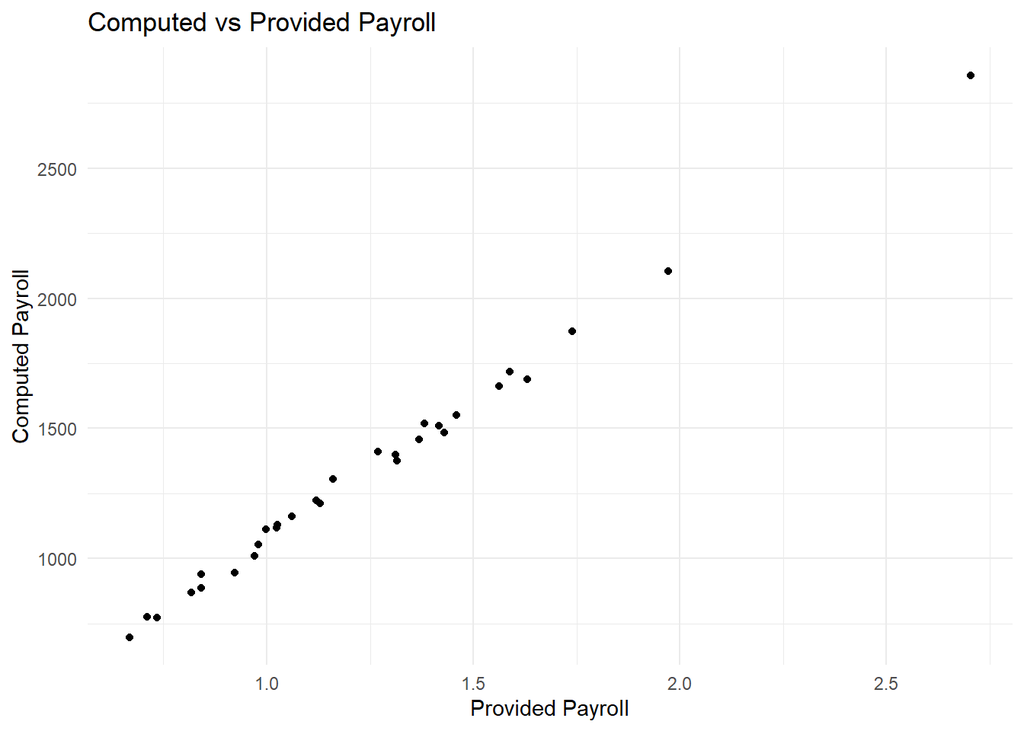

   ```r
   ggplot(mlb_check,
          aes(x = payroll_provided,
              y = payroll_computed)) +
     geom_point() +
     geom_abline(slope = 1, intercept = 0, linetype = "dashed") +
     labs(
       title = "Computed vs Provided Payroll",
       x = "Provided Payroll",
       y = "Computed Payroll"
     ) +
     theme_minimal()
   ```

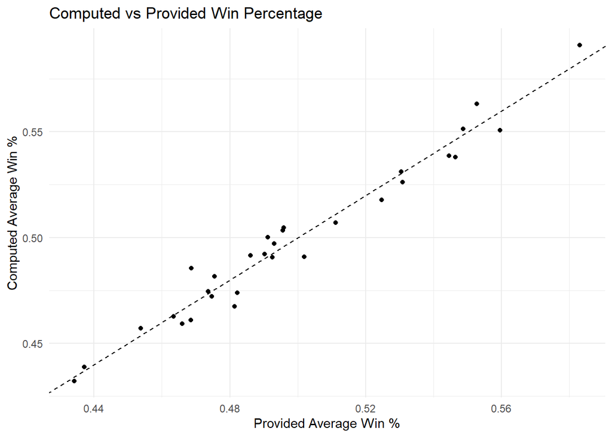

   ```r
   ggplot(mlb_check,
          aes(x = pct_wins_provided,
              y = pct_wins_computed)) +
     geom_point() +
     geom_abline(slope = 1, intercept = 0, linetype = "dashed") +
     labs(
       title = "Computed vs Provided Win Percentage",
       x = "Provided Average Win %",
       y = "Computed Average Win %"
     ) +
     theme_minimal()
   ```

4. Comment on numerical differences (if any).

   Check Numerical Differences

   ```r
   mlb_check %>%
     mutate(
       payroll_diff = payroll_computed - payroll_provided,
       pct_diff = pct_wins_computed - pct_wins_provided
     ) %>%
     summarise(
       max_payroll_diff = max(abs(payroll_diff)),
       max_pct_diff = max(abs(pct_diff))
     )
   ```

   ```
   ## # A tibble: 1 × 2
   ##   max_payroll_diff max_pct_diff
   ##              <dbl>        <dbl>
   ## 1            2854.       0.0167
   ```

# **Part 3 – Exploratory Data Analysis (6 points)**

### 3.1 Trends Over Time (3 points)

- Faceted payroll vs year plot.

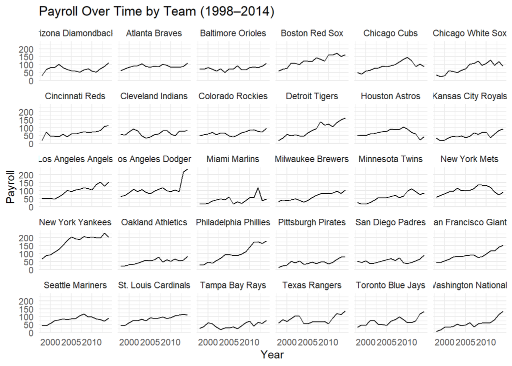

  ```r
  ggplot(mlb_yearly, aes(x = year, y = payroll)) +
    geom_line() +
    facet_wrap(~ team) +
    labs(
      title = "Payroll Over Time by Team (1998–2014)",
      x = "Year",
      y = "Payroll"
    ) +
    theme_minimal()
  ```

- Faceted win percentage vs year plot.

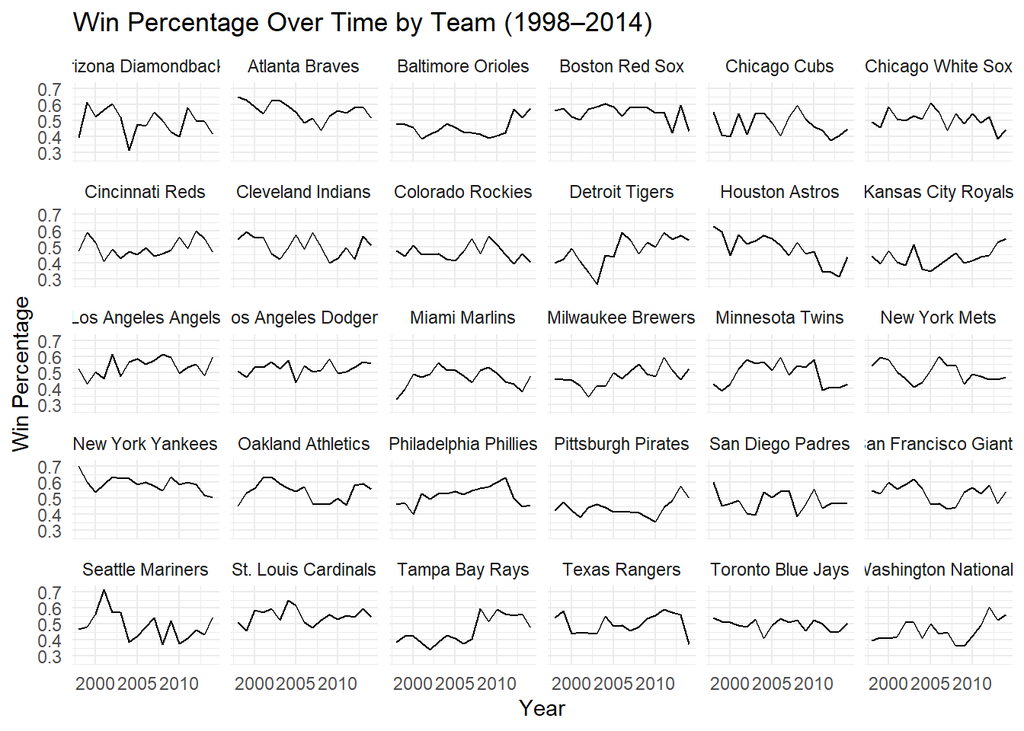

  ```r
  ggplot(mlb_yearly, aes(x = year, y = pct_wins)) +
    geom_line() +
    facet_wrap(~ team) +
    labs(
      title = "Win Percentage Over Time by Team (1998–2014)",
      x = "Year",
      y = "Win Percentage"
    ) +
    theme_minimal()
  ```

- Identify:
  - 3 highest payroll teams

  ```r
  mlb_aggregate %>%
    arrange(desc(payroll_aggregate)) %>%
    slice(1:3)
  ```

  ```
  ## # A tibble: 3 × 3
  ##   team                payroll_aggregate pct_wins_aggregate
  ##   <fct>                           <dbl>              <dbl>
  ## 1 New York Yankees                2857.              0.591
  ## 2 Boston Red Sox                  2104.              0.551
  ## 3 Los Angeles Dodgers             1874.              0.526
  ```

  - 3 highest win percentage teams

  ```r
  mlb_aggregate %>%
    arrange(desc(pct_wins_aggregate)) %>%
    slice(1:3)
  ```

  ```
  ## # A tibble: 3 × 3
  ##   team             payroll_aggregate pct_wins_aggregate
  ##   <fct>                        <dbl>              <dbl>
  ## 1 New York Yankees             2857.              0.591
  ## 2 Atlanta Braves               1518.              0.563
  ## 3 Boston Red Sox               2104.              0.551
  ```

- Provide short interpretation (≤5 sentences).

  Payroll generally increases over time for most teams, reflecting league-wide financial growth. However, win percentage fluctuates considerably from year to year, indicating performance variability. The teams with the highest aggregate payrolls are not always the same teams with the highest win percentages. While high-spending teams often perform well, payroll alone does not guarantee consistent success. This suggests that factors beyond payroll contribute to team performance.

### 3.2 Correlation Analysis (3 points)

- Compute Pearson correlation between aggregate payroll and aggregate win percentage.

```r
cor_test <- cor.test(
  mlb_aggregate$payroll_aggregate,
  mlb_aggregate$pct_wins_aggregate,
  method = "pearson"
)

cor_test
```

```
##
##  Pearson's product-moment correlation
##
## data:  mlb_aggregate$payroll_aggregate and mlb_aggregate$pct_wins_aggregate
## t = 5.7872, df = 28, p-value = 3.249e-06
## alternative hypothesis: true correlation is not equal to 0
## 95 percent confidence interval:
##  0.5145500 0.8675996
## sample estimates:
##       cor
## 0.7380096
```

- Test for statistical significance.

  ```r
  cor_test$estimate
  ```

  ```
  ##       cor
  ## 0.7380096
  ```

- Interpret magnitude (weak/moderate/strong).

The Pearson correlation between aggregate payroll and aggregate win percentage is r = 0.738. This indicates a strong positive relationship between team payroll and team performance over the 1998–2014 period. Teams that spent more overall tended to have higher average win percentages. The magnitude of 0.738 falls within the range typically classified as strong (0.60–0.79). This suggests that payroll is an important predictor of team success, although it does not perfectly explain performance differences.

# **Part 4 – Regression Modeling (8 points)**

## 4.1 Simple Linear Regression (3 points)

Fit:

$$\text{pct_wins_aggregate} = \beta_0 + \beta_1(\text{payroll_aggregate})
+ \epsilon$$

Report:

- Estimated slope
- p-value
- R²
- 95% confidence interval for slope

Interpret slope in practical terms.

First, we need to fit the model

```r
model_simple <- lm(
  pct_wins_aggregate ~ payroll_aggregate,
  data = mlb_aggregate
)

summary(model_simple)
```

```
##
## Call:
## lm(formula = pct_wins_aggregate ~ payroll_aggregate, data = mlb_aggregate)
##
## Residuals:
##       Min        1Q    Median        3Q       Max
## -0.039888 -0.014780 -0.001019  0.007697  0.067377
##
## Coefficients:
##                    Estimate Std. Error t value Pr(>|t|)
## (Intercept)       4.163e-01  1.494e-02  27.864  < 2e-16 ***
## payroll_aggregate 6.179e-05  1.068e-05   5.787 3.25e-06 ***
## ---
## Signif. codes:  0 '***' 0.001 '**' 0.01 '*' 0.05 '.' 0.1 ' ' 1
##
## Residual standard error: 0.02588 on 28 degrees of freedom
## Multiple R-squared:  0.5447, Adjusted R-squared:  0.5284
## F-statistic: 33.49 on 1 and 28 DF,  p-value: 3.249e-06
```

Extract the key quantities

```r
coef(model_simple)["payroll_aggregate"]
```

```
## payroll_aggregate
##      6.178595e-05
```

```r
r_squared <- summary(model_simple)$r.squared
cat("r squared:", r_squared)
```

```
## r squared: 0.5446582
```

```r
confint(model_simple, level = 0.95)
```

```
##                          2.5 %       97.5 %
## (Intercept)       3.857259e-01 0.4469391670
## payroll_aggregate 3.991671e-05 0.0000836552
```

The estimated slope coefficient is β₁ = 0.0000618, indicating a positive relationship between aggregate payroll and aggregate win percentage. The model explains 54.47% of the variation in team win percentage (R² = 0.545). The 95% confidence interval for the slope is [0.0000399, 0.0000837], which does not include zero, indicating statistical significance at the 5% level (p < 0.001).

In practical terms, this means that for each one-unit increase in aggregate payroll, average win percentage increases by approximately 0.0000618 units. This suggests that higher payroll spending is strongly associated with improved long-term team performance.

## 4.2 Regression Diagnostics (3 points)

Produce and interpret:

- Residual vs Fitted plot

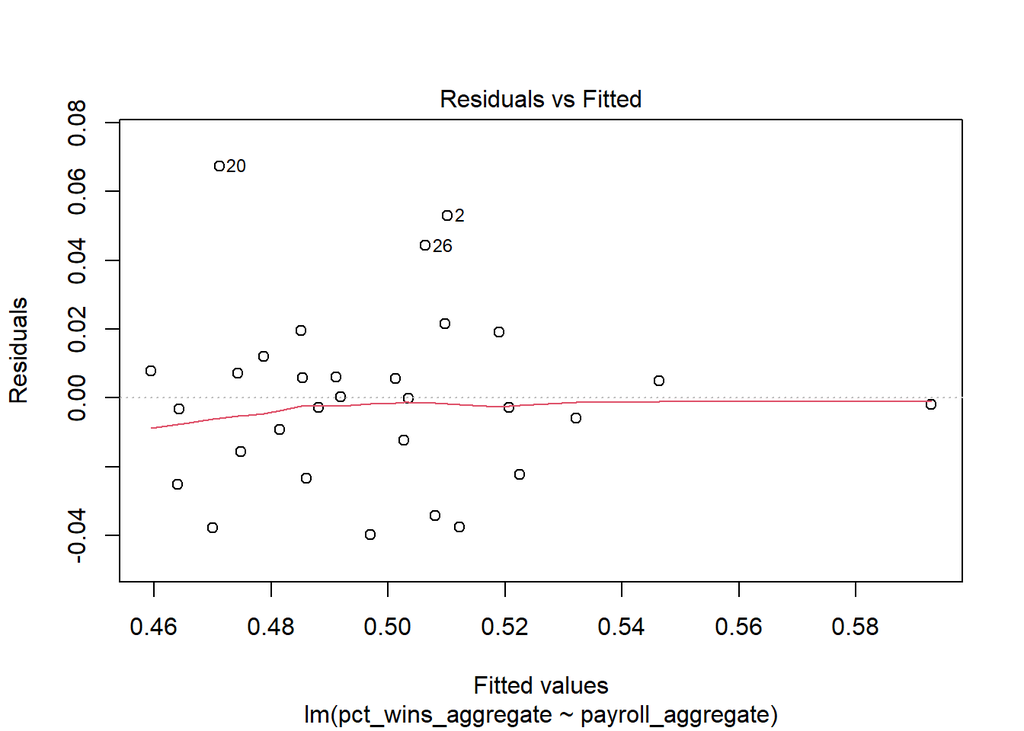

```r
plot(model_simple, which = 1)
```

- Q-Q plot

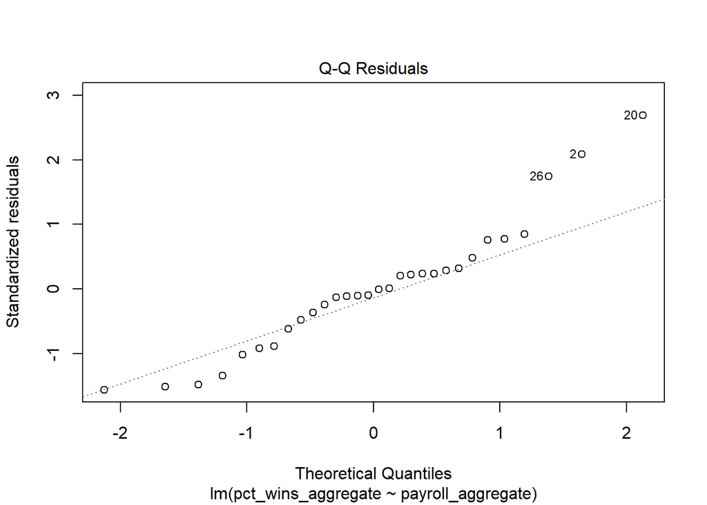

```r
plot(model_simple, which = 2)
```

- Scale-Location plot

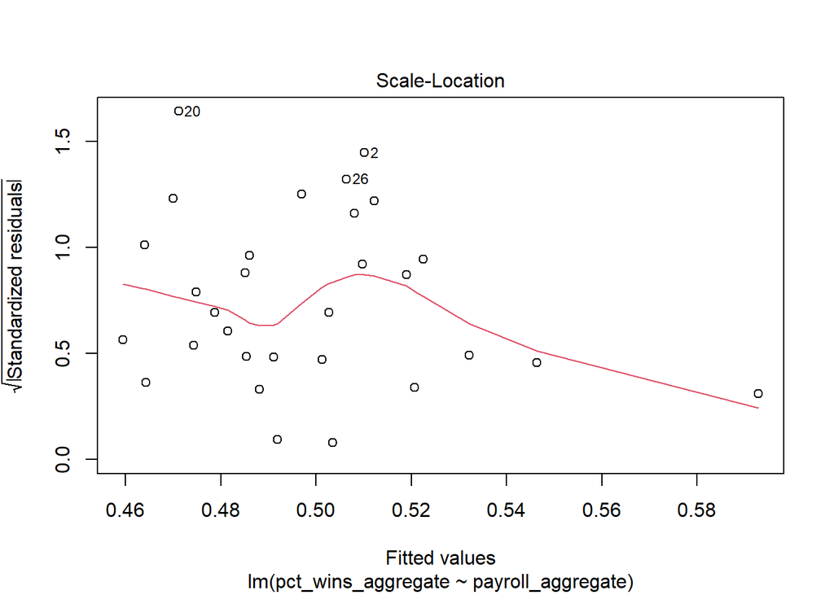

```r
plot(model_simple, which = 3)
```

- Cook’s Distance

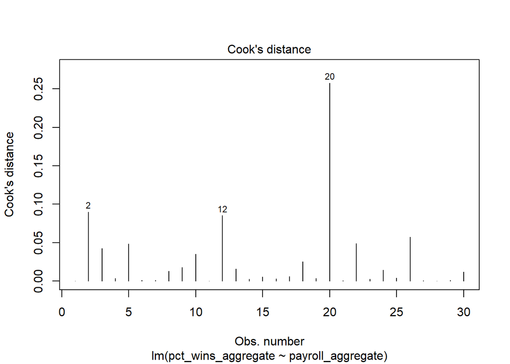

```r
plot(model_simple, which = 4)
```

```r
cooksD <- cooks.distance(model_simple)
which(cooksD > 4/30)
```

```
## 20
## 20
```

Address:

- Linearity
- Normality
- Homoscedasticity
- Influential observations

Comment clearly on whether assumptions are satisfied.

The residuals versus fitted plot shows no clear curvature, suggesting that the linearity assumption is satisfied. The spread of residuals appears relatively constant, indicating no strong evidence of heteroscedasticity.

The Scale-Location plot does not show a clear funnel shape, supporting the assumption of homoscedasticity.

## 4.3 Outlier & Influence Analysis (2 points)

- Identify any influential teams (high leverage or Cook’s D).

```r
cooksD <- cooks.distance(model_simple)

# threshold
threshold <- 4 / nrow(mlb_aggregate)

which(cooksD > threshold)
```

```
## 20
## 20
```

To see which team:

```r
mlb_aggregate[which(cooksD > threshold), ]
```

```
## # A tibble: 1 × 3
##   team              payroll_aggregate pct_wins_aggregate
##   <fct>                         <dbl>              <dbl>
## 1 Oakland Athletics              888.              0.539
```

```r
hat_vals <- hatvalues(model_simple)

which(hat_vals > 2 * mean(hat_vals))
```

```
##  4 19
##  4 19
```

- Remove one influential team and refit the model.

```r
mlb_no_oak <- mlb_aggregate %>%
  filter(team != "Oakland Athletics")

model_no_oak <- lm(pct_wins_aggregate ~ payroll_aggregate,
                   data = mlb_no_oak)

summary(model_no_oak)
```

```
##
## Call:
## lm(formula = pct_wins_aggregate ~ payroll_aggregate, data = mlb_no_oak)
##
## Residuals:
##       Min        1Q    Median        3Q       Max
## -0.037361 -0.011169  0.001794  0.011739  0.054386
##
## Coefficients:
##                    Estimate Std. Error t value Pr(>|t|)
## (Intercept)       4.068e-01  1.346e-02  30.216  < 2e-16 ***
## payroll_aggregate 6.719e-05  9.521e-06   7.057 1.38e-07 ***
## ---
## Signif. codes:  0 '***' 0.001 '**' 0.01 '*' 0.05 '.' 0.1 ' ' 1
##
## Residual standard error: 0.02268 on 27 degrees of freedom
## Multiple R-squared:  0.6485, Adjusted R-squared:  0.6354
## F-statistic:  49.8 on 1 and 27 DF,  p-value: 1.378e-07
```

- Compare slope and R².

| Model | Slope | R² |
| --- | --- | --- |

| Original Model | 0.0000618 | 0.5447 |
| --- | --- | --- |

| Without Oakland Athletics | 0.0000672 | 0.6485 |
| --- | --- | --- |

The slope **increased slightly**.

This means the relationship between payroll and win percentage becomes **stronger** after removing Oakland.

- Comment on model stability.

Oakland Athletics was identified as an influential observation based on Cook’s Distance. After removing the team and refitting the model, the slope increased from 0.0000618 to 0.0000672, and R² increased from 0.5447 to 0.6485. This indicates that Oakland weakened the observed relationship between payroll and win percentage. Without Oakland, payroll explains nearly 65% of the variation in win percentage, suggesting a stronger and more stable relationship. While the model remains statistically significant in both cases, the increase in explanatory power indicates that the regression is moderately sensitive to influential observations.

## **Part 5 – Model Extension and Critical Thinking (4 points)**

## 5.1 Log Transformation (2 points)

Payroll is often right-skewed.

- Fit a model using `log(payroll_aggregate)`.

```r
model_log <- lm(pct_wins_aggregate ~ log(payroll_aggregate),
                data = mlb_aggregate)

summary(model_log)
```

```
##
## Call:
## lm(formula = pct_wins_aggregate ~ log(payroll_aggregate), data = mlb_aggregate)
##
## Residuals:
##       Min        1Q    Median        3Q       Max
## -0.044103 -0.016055 -0.001113  0.015035  0.070427
##
## Coefficients:
##                        Estimate Std. Error t value Pr(>|t|)
## (Intercept)            -0.11402    0.11084  -1.029    0.312
## log(payroll_aggregate)  0.08575    0.01551   5.530 6.53e-06 ***
## ---
## Signif. codes:  0 '***' 0.001 '**' 0.01 '*' 0.05 '.' 0.1 ' ' 1
##
## Residual standard error: 0.02651 on 28 degrees of freedom
## Multiple R-squared:  0.522,  Adjusted R-squared:  0.505
## F-statistic: 30.58 on 1 and 28 DF,  p-value: 6.525e-06
```

- Compare R² and residual behavior.

```r
summary(model_simple)$r.squared
```

```
## [1] 0.5446582
```

```r
summary(model_log)$r.squared
```

```
## [1] 0.5220482
```

- Does the transformation improve the model?

No, the log transformation does not improve the model.

- R² decreased from 0.545 → 0.522
- Residual standard error increased slightly
- The linear model explains more variation in win percentage

Although payroll is right-skewed, the simple linear specification fits slightly better for aggregate data.

However, the log model is still statistically significant: p<0.001

This suggests payroll still strongly predicts win percentage even after transformation.

**Conclusion**:

The log-transformed model was estimated to address the right-skewness of payroll. However, the R² decreased from 0.545 in the linear model to 0.522 in the log model, and the residual standard error increased slightly. Although the coefficient on log(payroll) remains statistically significant (p < 0.001), the transformation does not improve overall explanatory power. Therefore, the simple linear model provides a slightly better fit for aggregate team performance.

## 5.2 Efficiency Metric (2 points)

Define efficiency:

$$\text{Efficiency} = \frac{\text{Win Percentage}}{\text{Payroll}}$$

- Identify top 3 most efficient teams.

```r
mlb_efficiency <- mlb_aggregate %>%
  mutate(efficiency = pct_wins_aggregate / payroll_aggregate)

mlb_efficiency
```

```
## # A tibble: 30 × 4
##    team                 payroll_aggregate pct_wins_aggregate efficiency
##    <fct>                            <dbl>              <dbl>      <dbl>
##  1 Arizona Diamondbacks             1223.              0.492   0.000402
##  2 Atlanta Braves                   1518.              0.563   0.000371
##  3 Baltimore Orioles                1305.              0.457   0.000350
##  4 Boston Red Sox                   2104.              0.551   0.000262
##  5 Chicago Cubs                     1552.              0.475   0.000306
##  6 Chicago White Sox                1375.              0.507   0.000369
##  7 Cincinnati Reds                  1119.              0.491   0.000439
##  8 Cleveland Indians                1113.              0.505   0.000453
##  9 Colorado Rockies                 1129.              0.463   0.000410
## 10 Detroit Tigers                   1484.              0.474   0.000319
## # ℹ 20 more rows
```

```r
top3_eff <- mlb_efficiency %>%
  arrange(desc(efficiency)) %>%
  slice(1:3)

top3_eff
```

```
## # A tibble: 3 × 4
##   team              payroll_aggregate pct_wins_aggregate efficiency
##   <fct>                         <dbl>              <dbl>      <dbl>
## 1 Miami Marlins                  698.              0.467   0.000669
## 2 Oakland Athletics              888.              0.539   0.000607
## 3 Tampa Bay Rays                 776.              0.461   0.000594
```

- Discuss whether efficiency aligns with regression results.

From regression:

- Payroll has a strong positive effect on win percentage.
- Higher spending generally leads to better performance.

But efficiency shows:

- Some lower-payroll teams generate strong performance relative to spending.
- Oakland was influential because it performs well without extremely high payroll.

This explains why removing Oakland increased R², they do not perfectly follow the “spend more, win more” pattern.

- Relate findings briefly to the *Moneyball* concept.

The “Moneyball” strategy, popularized by the book Moneyball, is associated with the Oakland Athletics under general manager Billy Beane.

Moneyball emphasizes:

- Data-driven decision making
- Identifying undervalued players
- Maximizing wins per dollar spent

Your efficiency results support this idea:

- Oakland appears among the most efficient teams.
- They achieve relatively high win percentages despite lower payroll compared to big-market teams.

**Conclusion:**

The efficiency analysis identifies Miami Marlins, Oakland Athletics, and Tampa Bay Rays as the three most efficient teams in terms of wins per payroll dollar. While the regression results confirm that higher payroll is strongly associated with higher win percentage, the efficiency metric reveals that some teams outperform expectations relative to their spending. Notably, Oakland Athletics appears both as an influential observation and as one of the most efficient teams. This aligns with the Moneyball concept, which emphasizes strategic player evaluation and cost efficiency rather than simply increasing payroll. Overall, payroll significantly influences performance, but efficient resource allocation can partially offset financial disadvantages.

# **Part 6 – Presentation and Interpretation Quality (2 points)**

- Clear tables and plots
- Correct labeling
- Concise but insightful explanations
- Logical structure